# Analysis of Illegal Immigration and Rape in US States

Franco Krepel

2024-10-26

## 1. Introduction

### Research Question

*What is the effect of illegal immigration on crime rates in different states?*

This question is relevant because immigration, particularly illegal immigration, is often linked to discussions about public safety and crime. As we are coming up to the US elections, the topic of illegal immigration has been exasperated and is a main concern that both the Democratic and Republican party aim to address. Understanding whether or not a significant relationship exists between these variables is crucial for policy-making and public discourse. Furthermore, considering variables like police presence and population will help identify whether the link between immigration and crime is straightforward or if other factors are influencing crime rates.

## 2. Data

### Data Description

The dataset includes state-level data from 2000-2022, covering:

- **Total Crime**: The total number of crimes committed per year in each state.
- **Illegal Immigration**: The estimated number of illegal immigrants residing in each state for each year.
- **Officers per 1,000 People**: This measures the police presence, normalized by population.
- **Population**: The total population in each state per year.

### Frequency

- The data is aggregated annually, which makes it suitable for identifying trends and relationships over time. However, it limits the ability to explore short-term fluctuations.

### Potential Limitations

- **Time Frequency**: The data is annual, and using monthly data might reveal more granular trends, especially for crime rates.
- **Accuracy of Immigration Estimates**: The estimates of illegal immigration are inherently uncertain due to the hidden nature of the population.
- **Unobserved Factors**: Socio-economic factors such as poverty rates, unemployment, and education levels could also influence crime but are not accounted for in the current dataset.

Cleaning up Crime and Immigration datasets (Using rape for now)

```r
# List of state CSV files for crime data
state_files <- c("Rape_Data/CA_rape.csv", "Rape_Data/TX_rape.csv", "Rape_Data/FL_rape.csv", "Rape_Data/NJ_rape.csv", "Rape_Data/IL_rape.csv", "Rape_Data/NY_rape.csv", "Rape_Data/NC_rape.csv", "Rape_Data/GA_rape.csv", "Rape_Data/WA_rape.csv", "Rape_Data/AZ_rape.csv")

# Function to process each crime and clearance file
process_file <- function(file) {
  # Read the CSV file
  data <- read_csv(file)

  # Separate the first two rows for Crime and Clearance counts
  crime_data <- data[1, ]  # First row is for Crime
  clearance_data <- data[2, ]  # Second row is for Clearances

  # Extract the full state name from the series (assuming it comes first in the string)
  extract_state <- function(series_str) {
    str_extract(series_str, "^[A-Za-z\\s]+") %>% str_trim()  # Extract state name and trim white spaces
  }

  # Convert the wide format to long format for crime data
  crime_long <- crime_data %>%
    pivot_longer(-series, names_to = "Date", values_to = "Value") %>%
    mutate(State = extract_state(series), Type = "Crime") %>%
    select(-series)

  # Convert the wide format to long format for clearance data
  clearance_long <- clearance_data %>%
    pivot_longer(-series, names_to = "Date", values_to = "Value") %>%
    mutate(State = extract_state(series), Type = "Clearance") %>%
    select(-series)

  # Combine the crime and clearance data
  combined_long <- bind_rows(crime_long, clearance_long)

  return(combined_long)
}

# Apply the process_file function to each file and combine the results
all_states_data <- map_dfr(state_files, process_file)

# Filter to only include crime data (excluding clearance)
crime_data <- all_states_data %>%
  filter(Type == "Crime")

# Extract Year from Date and sum the values by year and state
crime_data <- crime_data %>%
  mutate(Year = substr(Date, 4, 7)) %>%  # Extract the year from the "Date" column
  mutate_at(c('Year'), as.numeric) %>%
  group_by(State, Year) %>%
  summarize(Rape = sum(Value, na.rm = TRUE))

# Now for the illegal immigration dataset
illegal_immigration <- read_csv("illegal_immigration.csv")
# Reshape the illegal immigration data from wide to long format
illegal_immigration <- illegal_immigration %>%
  pivot_longer(cols = -State, names_to = "Year", values_to = "Illegal_Immigration") %>%
  mutate_at(c('Year'), as.numeric)

# Combine crime data and illegal immigration data
combined_data <- crime_data %>%
  inner_join(illegal_immigration, by = c("State", "Year"))

### Now Add Police Data ###

# List of police files for each state (same states as above)
police_files <- c("Police_Data/CA_police.csv", "Police_Data/TX_police.csv", "Police_Data/FL_police.csv", "Police_Data/NJ_police.csv", "Police_Data/IL_police.csv", "Police_Data/NY_police.csv", "Police_Data/NC_police.csv", "Police_Data/GA_police.csv", "Police_Data/WA_police.csv", "Police_Data/AZ_police.csv")

# Function to extract the full state name based on file names
extract_full_state_name <- function(file) {
  state_map <- c("CA" = "California", "TX" = "Texas", "FL" = "Florida", "NJ" = "New Jersey",
                 "IL" = "Illinois", "NY" = "New York", "NC" = "North Carolina",
                 "GA" = "Georgia", "WA" = "Washington", "AZ" = "Arizona")

  state_abbr <- str_extract(file, "(?<=/)[A-Z]{2}(?=_)")  # Extract the state abbreviation from the file name
  full_state <- state_map[[state_abbr]]  # Map abbreviation to full state name

  return(full_state)
}

# Function to process police data for each state
process_police_file <- function(file) {
  data <- read_csv(file)

  # Reshape the police data from wide to long format
  police_long <- data %>%
    pivot_longer(-series, names_to = "Year", values_to = "Officers_per_1000") %>%
    mutate(State = extract_full_state_name(file)) %>%
    select(State, Year, Officers_per_1000) %>%
    mutate_at(c('Year'), as.numeric)

  return(police_long)
}

# Apply the process_police_file function to each police file
police_data <- map_dfr(police_files, process_police_file)

# Merge the police data with the combined crime and immigration data
final_combined_data <- combined_data %>%
  inner_join(police_data, by = c("State", "Year"))

## POPULATION DATA ##

# Read in the state population data
population_data <- read_csv("state_populations.csv")

# Reshape population data from wide to long format
population_long <- population_data %>%
  pivot_longer(cols = -Year, names_to = "State", values_to = "Population") %>%
  mutate_at(c('Year'), as.numeric)

# Now merge the population data with the existing combined dataset
final_combined_data_with_population <- final_combined_data %>%
  inner_join(population_long, by = c("State", "Year"))

# Save the final combined dataset to a CSV file
write_csv(final_combined_data_with_population, "final_combined_crime_immigration_police_population_data.csv")
```

Loading the combined data

```r
crime_immigration <- read_csv("final_combined_crime_immigration_police_population_data.csv")

crime_immigration <- crime_immigration %>%
  mutate(
    Rape_Per_Capita = Rape / Population * 1000,
    Illegal_Immigration_Per_capita = Illegal_Immigration / Population * 1000
    )

head(crime_immigration)
```

```
## # A tibble: 6 × 8
##   State    Year  Rape Illegal_Immigration Officers_per_1000 Population
##   <chr>   <dbl> <dbl>               <dbl>             <dbl>      <dbl>
## 1 Arizona  2000  1577                 330              2.04      5273.
## 2 Arizona  2005  1948                 480              1.99      6029.
## 3 Arizona  2006  2398                 490              1.94      6168.
## 4 Arizona  2007  2128                 530              2.04      6280.
## 5 Arizona  2008  2153                 560              2.02      6343.
## 6 Arizona  2009  2225                 460              2         6407.
## # ℹ 2 more variables: Rape_Per_Capita <dbl>,
## #   Illegal_Immigration_Per_capita <dbl>
```

## 3. Description

### Summary Statistics

```r
summary(crime_immigration)
```

```
##     State                Year           Rape       Illegal_Immigration
##  Length:180         Min.   :2000   Min.   :    0   Min.   : 170.0
##  Class :character   1st Qu.:2008   1st Qu.: 2138   1st Qu.: 360.0
##  Mode  :character   Median :2012   Median : 3126   Median : 470.0
##                     Mean   :2012   Mean   : 5082   Mean   : 812.1
##                     3rd Qu.:2017   3rd Qu.: 6990   3rd Qu.: 722.5
##                     Max.   :2022   Max.   :27046   Max.   :2910.0
##  Officers_per_1000   Population    Rape_Per_Capita
##  Min.   :1.330     Min.   : 5273   Min.   :  0.0
##  1st Qu.:2.080     1st Qu.: 8841   1st Qu.:203.9
##  Median :2.395     Median :11759   Median :302.9
##  Mean   :2.515     Mean   :15912   Mean   :313.2
##  3rd Qu.:2.913     3rd Qu.:19917   3rd Qu.:374.4
##  Max.   :5.000     Max.   :39503   Max.   :886.7
##  Illegal_Immigration_Per_capita
##  Min.   :18.64
##  1st Qu.:35.20
##  Median :41.96
##  Mean   :46.45
##  3rd Qu.:52.74
##  Max.   :88.28
```

### Figures and Tables

1. **Illegal Immigration vs. Rape Rates by Year**

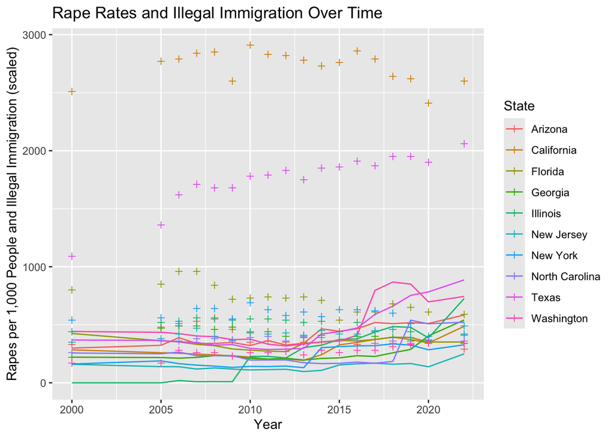

```r
ggplot(crime_immigration, aes(x = Year, y = Rape_Per_Capita, color = State)) +
  geom_line() +
  geom_point(aes(y = Illegal_Immigration), shape = 3) +
  labs(title = "Rape Rates and Illegal Immigration Over Time",
       x = "Year",
       y = "Rapes per 1,000 People and Illegal Immigration (scaled)",
       color = "State")
```

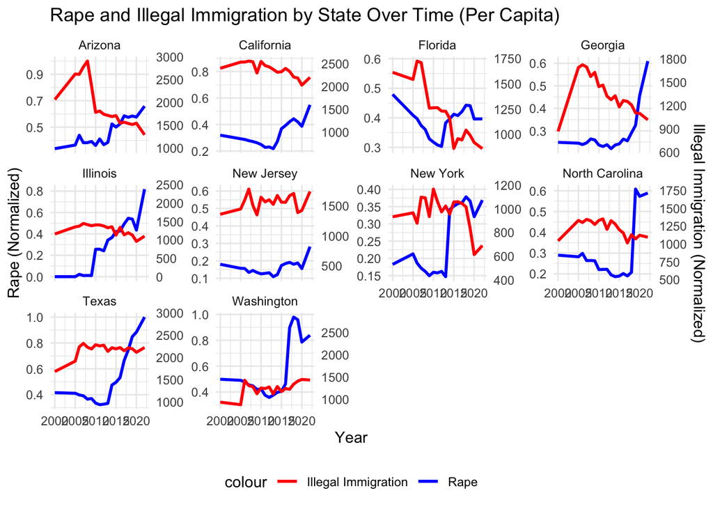

```r
library(scales)
# 2 Y-axes: Total Rape and Illegal Immigration
ggplot(crime_immigration, aes(x = Year)) +
  geom_line(aes(y = Rape_Per_Capita / max(Rape_Per_Capita), color = "Rape"), size = 1) + # Normalize rape data
  geom_line(aes(y = Illegal_Immigration_Per_capita / max(Illegal_Immigration_Per_capita), color = "Illegal Immigration"), size = 1) + # Normalize immigration data
  facet_wrap(~ State, scales = "free_y") + # Facet by state for better comparison
  scale_y_continuous(name = "Rape (Normalized)",
                     sec.axis = sec_axis(~ . * max(crime_immigration$Illegal_Immigration),
                                         name = "Illegal Immigration (Normalized)")) + # Add secondary axis for immigration
  labs(title = "Rape and Illegal Immigration by State Over Time (Per Capita)",
       x = "Year") +
  scale_color_manual(values = c("Rape" = "blue", "Illegal Immigration" = "red")) + # Set colors for lines
  theme_minimal() +
  theme(legend.position = "bottom")
```

- In this second graph that compares the time trends by state, states such as Texas and New Jersey show sharper increases in both rape and immigration levels (trends that slightly follow each other), where Florida the trends follow each other but downwards
- Arizona shows a counterintuitive trend where immigration rates have decreased, while rape rates shows some fluctuations upwards.
- The mixed results suggest that while some states show a stronger relationship between illegal immigration and rape, most do not
- This graph helps demonstrate the variability of these relationships across different states. The state-specific nature of the data suggests the possibility of other local factors, such as policy differences, law enforcement strategies, or economic conditions, which need further exploration to determine a clearer relationship.
2. **Police Presence vs. Rape Rates**

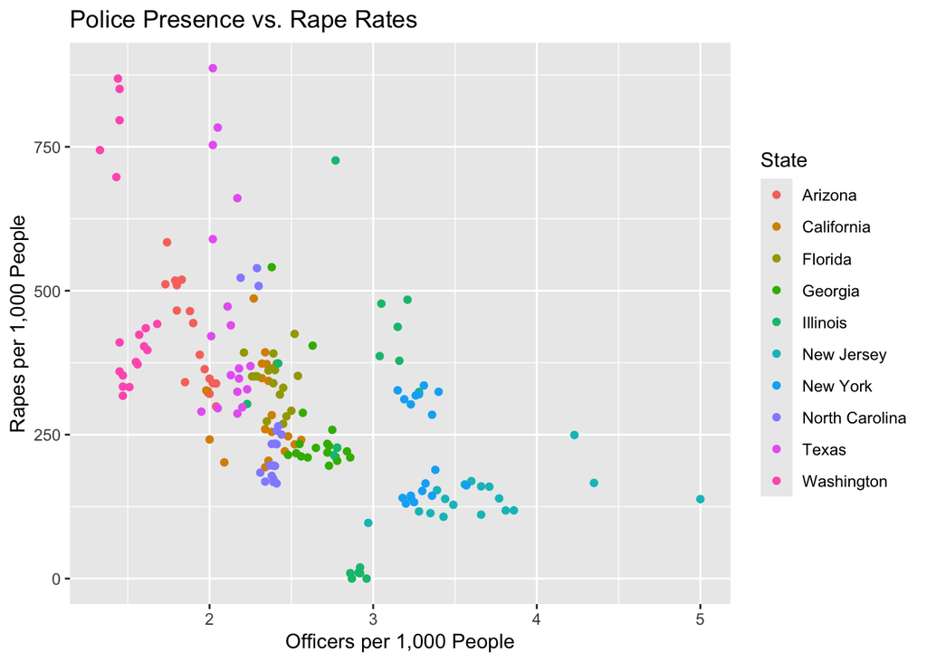

```r
ggplot(crime_immigration, aes(x = Officers_per_1000, y = Rape_Per_Capita, color = State)) +
  geom_point() +
  labs(title = "Police Presence vs. Rape Rates",
       x = "Officers per 1,000 People",
       y = "Rapes per 1,000 People")
```

```r
crime_immigration <- crime_immigration %>%
  mutate(
    Illegal_Immigration_Per_capita = Illegal_Immigration / Population * 1000
  )
cor(crime_immigration %>% select(Rape_Per_Capita, Illegal_Immigration_Per_capita, Officers_per_1000, Population))
```

```
##                                Rape_Per_Capita Illegal_Immigration_Per_capita
## Rape_Per_Capita                     1.00000000                     0.09709334
## Illegal_Immigration_Per_capita      0.09709334                     1.00000000
## Officers_per_1000                  -0.58588703                    -0.24347166
## Population                          0.06149447                     0.49860105
##                                Officers_per_1000  Population
## Rape_Per_Capita                       -0.5858870  0.06149447
## Illegal_Immigration_Per_capita        -0.2434717  0.49860105
## Officers_per_1000                      1.0000000 -0.02447630
## Population                            -0.0244763  1.00000000
```

- The correlation between **Rape per Capita and Illegal Immigration per Capita** is quite weak (0.097), indicating that there is no significant direct relationship between the rate of illegal immigration and the rate of rape per capita in the dataset. This suggests that the levels of illegal immigration are not a strong predictor of changes in the rape rate across these states. Rape per Capita and Officers per 1,000 People:
- The negative correlation (-0.586) between **Rape per Capita and Officers per 1,000 People** remains moderate. This indicates that states with a higher police presence tend to have lower rates of rape per capita. This relationship suggests that having more law enforcement per capita could potentially help reduce rape rates, which aligns with the common understanding that a stronger law enforcement presence can act as a deterrent to crime.
- The correlation between **Illegal Immigration per Capita and Officers per 1,000 People** is negative but weak (-0.243). This suggests a slight tendency for states with higher rates of illegal immigration per capita to have fewer police officers per 1,000 people, but this relationship is not strong enough to draw any definitive conclusions. It may indicate resource constraints in states with higher immigration rates, or it could simply reflect other unobserved factors. Population and Rape per Capita:
- The correlation between **Population and Rape per Capita** is very weak (0.061), indicating that the size of the population does not significantly affect the rape rate on a per capita basis. In other words, larger states do not necessarily have higher rates of rape when adjusted for population. Population and Illegal Immigration per Capita:
- The moderate positive correlation (0.499) between **Population and Illegal Immigration per Capita** suggests that states with larger populations tend to have higher levels of illegal immigration per capita. This could be due to the fact that more populous states, such as California and Texas, are more likely to attract higher rates of immigration due to their economic opportunities and border proximity. Population and Officers per 1,000 People:
- The correlation between **Population and Officers per 1,000 People** is nearly zero (-0.024), indicating that population size does not meaningfully impact the number of police officers per capita across states. This implies that larger populations do not necessarily correspond to more or fewer police officers per capita, meaning police staffing levels might not be directly related to the overall population size.

### Possible Improvements

Given the relatively weak correlations between Rape per Capita and Illegal Immigration per Capita, it would be useful to:

- Run regression models to better understand potential causal relationships, controlling for other confounding factors such as economic conditions, poverty rates, or changes in law enforcement policies.
- Explore temporal trends more closely by looking at how crime rates and immigration rates have evolved over time within specific states, as this might reveal more nuanced patterns not visible in the aggregate correlation analysis.
- Investigate other types of crime beyond rape to see if there are different patterns when considering violent crime, property crime, or overall crime rates in relation to illegal immigration and policing levels.

### Potential Confounding Factors

There are several potential confounding factors that need to be considered when analyzing the relationship between crime rates, illegal immigration, and police presence.

#### Economic Factors:

- Unemployment rates, poverty levels, and income inequality are well-established contributors to crime rates. States with higher illegal immigration levels might also experience varying economic conditions that can influence crime rates. If these economic factors are not controlled for, the effect of illegal immigration on crime could be misrepresented.

#### Urbanization and Population Density:

States with larger urban centers or higher population densities, like California or New York, tend to have both higher crime rates and more immigration. Urban areas often experience more crime due to various socio-economic factors, and without controlling for the degree of urbanization, it’s hard to attribute changes in crime rates to illegal immigration or police presence.

#### Changes in Law Enforcement Policies:

States may have introduced new law enforcement policies (e.g., stricter immigration laws, changes in policing tactics, or reform of the criminal justice system) that affect both crime rates and how immigration is enforced. If these policies are not accounted for, they could confound the relationship between illegal immigration and crime. For example, more aggressive immigration enforcement could reduce illegal immigration, but at the same time, it might also affect crime rates indirectly.

#### Migration Patterns and Other Immigration Types:

Focusing solely on illegal immigration might obscure broader trends in legal immigration or internal migration (people moving between states), both of which could also influence crime rates. For example, states like California may experience large volumes of legal immigration, which might affect crime trends but is not captured by illegal immigration figures.

#### Demographic Changes:

States that experience large demographic shifts, including the age distribution or education levels of the population, may see changes in crime patterns. Younger populations, for instance, tend to have higher crime rates. Failing to account for such demographic changes could confound the analysis of illegal immigration’s impact on crime.

### Can We Infer Causal Relationships from the Descriptive Analysis?

**No**, we cannot infer causal relationships from this descriptive analysis alone. Correlation does not imply causation, and the correlations observed between illegal immigration, crime, and police presence could be driven by several of the confounding factors mentioned above. The descriptive statistics and visualizations are useful in identifying potential trends, but they do not account for all the underlying factors that could influence the relationship between the variables.

To properly infer causality, we would need to employ an empirical strategy that controls for these confounding variables. This would allow us to isolate the effect of illegal immigration on crime rates more accurately.

### Next Steps to Address Confounding Factors:

To address these concerns, we can pursue the following strategies:

1. **Multivariate Regression Analysis:**
- A multivariate regression would allow us to control for several variables at once, such as unemployment rates, poverty levels, urbanization, and demographic shifts. By including these additional factors, we can better isolate the effect of illegal immigration on crime rates.
- A Difference-in-Differences approach could be used if there are certain states that implemented new immigration or law enforcement policies at different times. This method would allow us to compare changes in crime rates between states with and without such policy changes, providing a clearer picture of the causal impact of immigration and police presence on crime.
2. **Instrumental Variable (IV) Approach:**
- An instrumental variable approach could be used to tackle potential endogeneity issues. For example, we could find an external instrument that affects immigration levels but not crime rates directly (like economic shocks in nearby countries leading to immigration increases). This would allow us to estimate the causal effect of illegal immigration on crime more accurately.
- To generalize findings beyond rape crimes, it may be beneficial to include other types of crime, such as property crimes, violent crimes, and drug-related offenses. This would give a more comprehensive view of the relationship between illegal immigration and overall crime trends.